# STA380, Part 2: Exercises

## **Association rule mining**

Reading the grocery transaction level data and getting the summary

```
## transactions as itemMatrix in sparse format with
##  9835 rows (elements/itemsets/transactions) and
##  169 columns (items) and a density of 0.02609146
##
## most frequent items:
##       whole milk other vegetables       rolls/buns             soda
##             2513             1903             1809             1715
##           yogurt          (Other)
##             1372            34055
##
## element (itemset/transaction) length distribution:
## sizes
##    1    2    3    4    5    6    7    8    9   10   11   12   13   14   15   16
## 2159 1643 1299 1005  855  645  545  438  350  246  182  117   78   77   55   46
##   17   18   19   20   21   22   23   24   26   27   28   29   32
##   29   14   14    9   11    4    6    1    1    1    1    3    1
##
##    Min. 1st Qu.  Median    Mean 3rd Qu.    Max.
##   1.000   2.000   3.000   4.409   6.000  32.000
##
## includes extended item information - examples:
##             labels
## 1 abrasive cleaner
## 2 artif. sweetener
## 3   baby cosmetics
```

The most frequent items being bought are whole milk, other vegetables, rolls/buns, soda and yogurt

```
## transactions in sparse format with
##  9835 transactions (rows) and
##  169 items (columns)
```

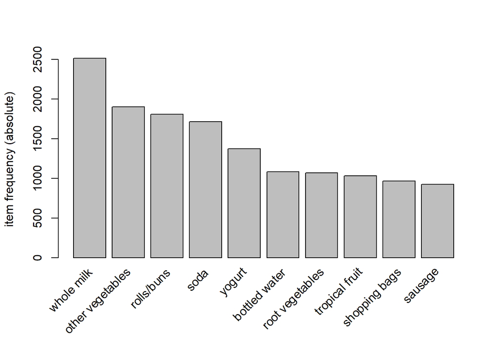

The top item purchased was whole milk with about 2,500 of the 9,836 transactions in the basket

```
## Apriori
##
## Parameter specification:
##  confidence minval smax arem  aval originalSupport maxtime support minlen
##        0.75    0.1    1 none FALSE            TRUE       5   0.002      1
##  maxlen target  ext
##      10  rules TRUE
##
## Algorithmic control:
##  filter tree heap memopt load sort verbose
##     0.1 TRUE TRUE  FALSE TRUE    2    TRUE
##
## Absolute minimum support count: 19
##
## set item appearances ...[0 item(s)] done [0.00s].
## set transactions ...[169 item(s), 9835 transaction(s)] done [0.00s].
## sorting and recoding items ... [147 item(s)] done [0.00s].
## creating transaction tree ... done [0.00s].
## checking subsets of size 1 2 3 4 5 done [0.00s].
## writing ... [39 rule(s)] done [0.00s].
## creating S4 object  ... done [0.00s].
```

```
##     lhs                                  rhs          support     confidence
## [1] {rice, root vegetables}           => {whole milk} 0.002440264 0.7741935
## [2] {herbs, tropical fruit}           => {whole milk} 0.002338587 0.8214286
## [3] {herbs, rolls/buns}               => {whole milk} 0.002440264 0.8000000
## [4] {butter milk, whipped/sour cream} => {whole milk} 0.002948653 0.7631579
## [5] {butter, onions}                  => {whole milk} 0.003050330 0.7500000
##     coverage    lift     count
## [1] 0.003152008 3.029922 24
## [2] 0.002846975 3.214783 23
## [3] 0.003050330 3.130919 24
## [4] 0.003863752 2.986732 29
## [5] 0.004067107 2.935237 30
```

```
## set of 39 rules
##
## rule length distribution (lhs + rhs):sizes
##  3  4  5
##  6 24  9
##
##    Min. 1st Qu.  Median    Mean 3rd Qu.    Max.
##   3.000   4.000   4.000   4.077   4.000   5.000
##
## summary of quality measures:
##     support           confidence        coverage             lift
##  Min.   :0.002034   Min.   :0.7500   Min.   :0.002440   Min.   :2.935
##  1st Qu.:0.002237   1st Qu.:0.7667   1st Qu.:0.002847   1st Qu.:3.000
##  Median :0.002440   Median :0.7742   Median :0.003050   Median :3.104
##  Mean   :0.002539   Mean   :0.7850   Mean   :0.003241   Mean   :3.327
##  3rd Qu.:0.002694   3rd Qu.:0.8000   3rd Qu.:0.003457   3rd Qu.:3.637
##  Max.   :0.004474   Max.   :0.8857   Max.   :0.005694   Max.   :4.578
##      count
##  Min.   :20.00
##  1st Qu.:22.00
##  Median :24.00
##  Mean   :24.97
##  3rd Qu.:26.50
##  Max.   :44.00
##
## mining info:
##        data ntransactions support confidence
##  grocery_df          9835   0.002       0.75
##                                                                              call
##  apriori(data = grocery_df, parameter = list(support = 0.002, confidence = 0.75))
```

We need a very low support (of 0.002) and a relatively low confidence (of 0.75) for apriori to learn association rules. This iteration gives us 39 rules.

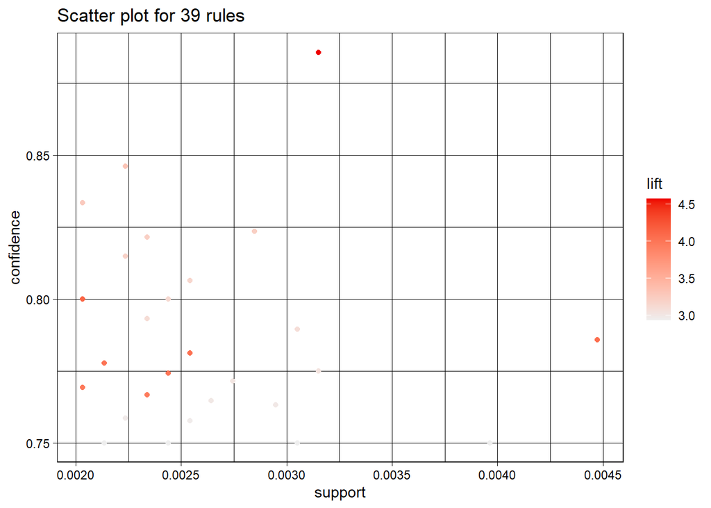

```
##     lhs                         rhs                    support confidence    coverage     lift count
## [1] {grapes,
##      tropical fruit,
##      whole milk}             => {other vegetables} 0.002033554  0.8000000 0.002541942 4.134524    20
## [2] {root vegetables,
##      sliced cheese,
##      whole milk}             => {other vegetables} 0.002440264  0.7741935 0.003152008 4.001153    24
## [3] {onions,
##      whipped/sour cream,
##      whole milk}             => {other vegetables} 0.002135231  0.7777778 0.002745297 4.019677    21
## [4] {fruit/vegetable juice,
##      root vegetables,
##      tropical fruit}         => {other vegetables} 0.002541942  0.7812500 0.003253686 4.037622    25
## [5] {citrus fruit,
##      root vegetables,
##      tropical fruit}         => {other vegetables} 0.004473818  0.7857143 0.005693950 4.060694    44
## [6] {fruit/vegetable juice,
##      root vegetables,
##      whole milk,
##      yogurt}                 => {other vegetables} 0.002033554  0.8000000 0.002541942 4.134524    20
## [7] {pip fruit,
##      root vegetables,
##      tropical fruit,
##      whole milk}             => {other vegetables} 0.002440264  0.7741935 0.003152008 4.001153    24
## [8] {citrus fruit,
##      root vegetables,
##      tropical fruit,
##      whole milk}             => {other vegetables} 0.003152008  0.8857143 0.003558719 4.577509    31
```

This shows that people generally tend to buy milk, fruits yogurt and vegetables together.

```
## Available control parameters (with default values):
## layout    =  stress
## circular  =  FALSE
## ggraphdots    =  NULL
## edges     =  <environment>
## nodes     =  <environment>
## nodetext  =  <environment>
## colors    =  c("#EE0000FF", "#EEEEEEFF")
## engine    =  ggplot2
## max   =  100
## verbose   =  FALSE
```

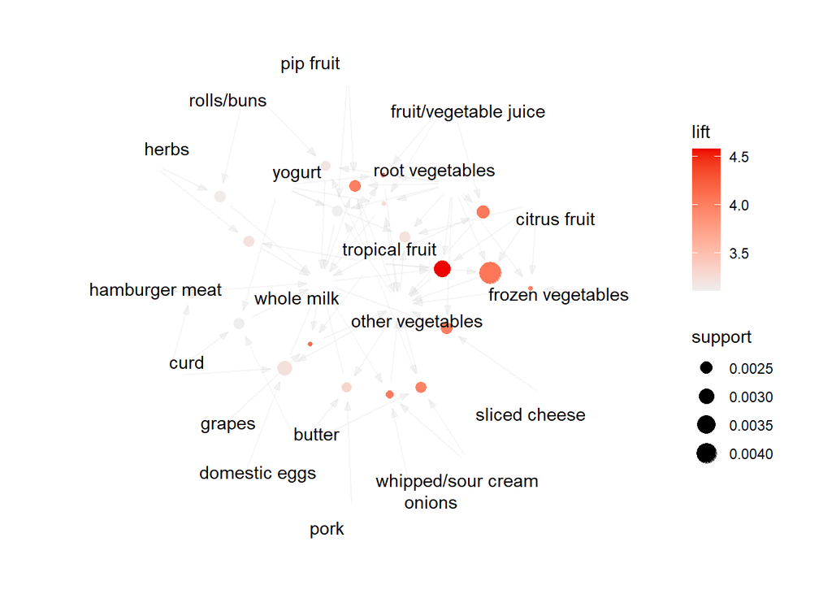

The plot reinforces the statement we make earlier that people tend to buy veggies, fruits and dairy products together.

We can assume the following based on the association rule model:

1. Whole Milk, yogurt and fruit and vegetable juices occur with high confidence indicating that people are probably buying these things together to make nutritious smoothies.
2. root vegetables and fruits occur with other vegetables indicating that people tend to make conscious nutritious choices.
3. citrus fruits and tropical fruits occur together, suggesting that people are preferring fruits that are native to hot and humid climates (tropical countries).
4. whole milk is associated with other vegetables majority of time with lift>4 indicating that there is 4 times a chance of people buying other vegetables when they buy whole milk.